# Meta data random forest and shap

Emily Yeo

2024-09-26

# Read in Aim 1 meta

```r
m1_dir <- "/Users/emily/projects/research/Stanislawski/comps/mutli-omic-predictions/data/clinical/transformed/aim1"

# Create the full file path using paste
test <- read.csv(paste(m1_dir, "test_samples_standard_clinical.csv", sep = "/"))
train <- read.csv(paste(m1_dir, "train_samples_standard_clinical.csv", sep = "/"))
all_m <- read.csv(paste(m1_dir, "a1_meta_Transformed_standard_clinical.csv", sep = "/"))
```

# Working on models

There seem to be a million ways to do this. So here I am exploring it

## randomForest package

https://modeloriented.github.io/treeshap/

```r
rf <-randomForest(outcome_BMI_fnl_BL~.,data=train, ntree=500)
print(rf)
```

```
##
## Call:
##  randomForest(formula = outcome_BMI_fnl_BL ~ ., data = train,      ntree = 500)
##                Type of random forest: regression
##                      Number of trees: 500
## No. of variables tried at each split: 4
##
##           Mean of squared residuals: 0.8444126
##                     % Var explained: 14.89
```

```r
floor(sqrt(ncol(train) - 1))
```

```
## [1] 3
```

The number of variables selected at each split is denoted by mtry in randomforest function. Step III : Find the optimal mtry value Select mtry value with minimum out of bag(OOB) error.

```
## mtry = 3  OOB error = 0.8661272
## Searching left ...
## mtry = 2     OOB error = 0.874515
## -0.009684263 0.01
## Searching right ...
## mtry = 4     OOB error = 0.875972
## -0.01136644 0.01
```

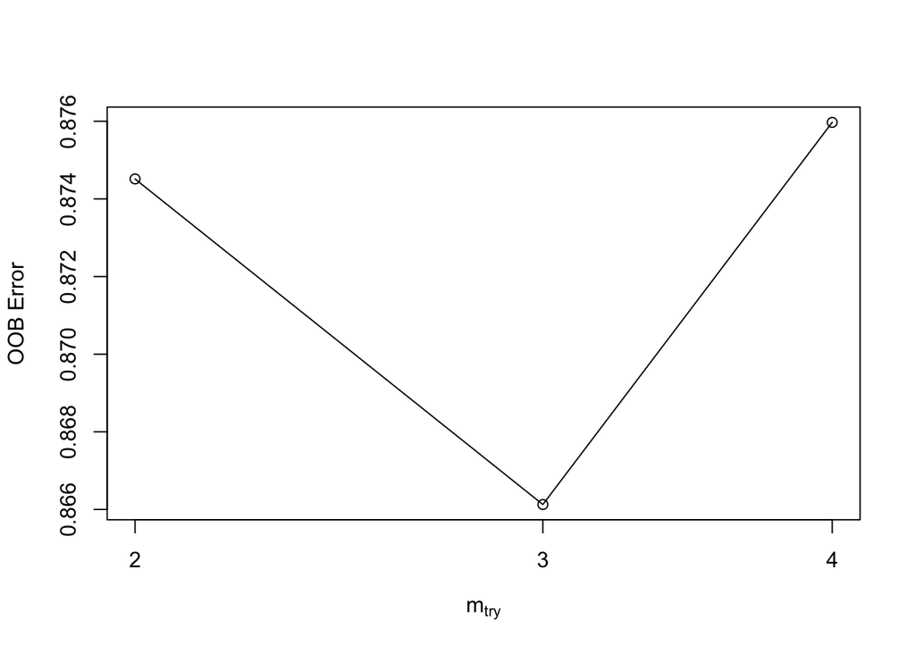

```r
mtry <- tuneRF(train[4:12],train$outcome_BMI_fnl_BL, ntreeTry=500,
               stepFactor=1.5,improve=0.01, trace=TRUE, plot=TRUE)
```

```r
best.m <- mtry[mtry[, 2] == min(mtry[, 2]), 1]
print(mtry)
```

```
##   mtry  OOBError
## 2    2 0.8745150
## 3    3 0.8661272
## 4    4 0.8759720
```

```r
print(best.m)
```

```
## [1] 3
```

Parameters in **tuneRF** function above

- The stepFactor specifies at each iteration, mtry is inflated (or deflated) by this value
- The improve specifies the (relative) improvement in OOB error must be by this much for the search to continue
- The trace specifies whether to print the progress of the search
- The plot specifies whether to plot the OOB error as function of mtry

```r
set.seed(71)
rf <-randomForest(outcome_BMI_fnl_BL~.,data=train[4:13], mtry=best.m,
                  importance=TRUE,ntree=500)
print(rf)
```

```
##
## Call:
##  randomForest(formula = outcome_BMI_fnl_BL ~ ., data = train[4:13],      mtry = best.m, importance = TRUE, ntree = 500)
##                Type of random forest: regression
##                      Number of trees: 500
## No. of variables tried at each split: 3
##
##           Mean of squared residuals: 0.8853595
##                     % Var explained: 10.76
```

```r
#Evaluate variable importance
importance(rf)
```

```
##                              %IncMSE IncNodePurity
## randomized_group          -1.6900169      1.505851
## sex                        0.9007495      1.555104
## age                        0.2972976     13.027334
## Triglyceride_lipid_BL      2.9857215     18.611732
## HDL_Total_Direct_lipid_BL -2.3930358     10.075533
## LDL_Calculated_BL         -2.7865500      9.901979
## Glucose_BL                -0.2475427     12.067715
## Insulin_endo_BL           15.5272435     21.714468
## HOMA_IR_BL                14.0839805     27.301253
```

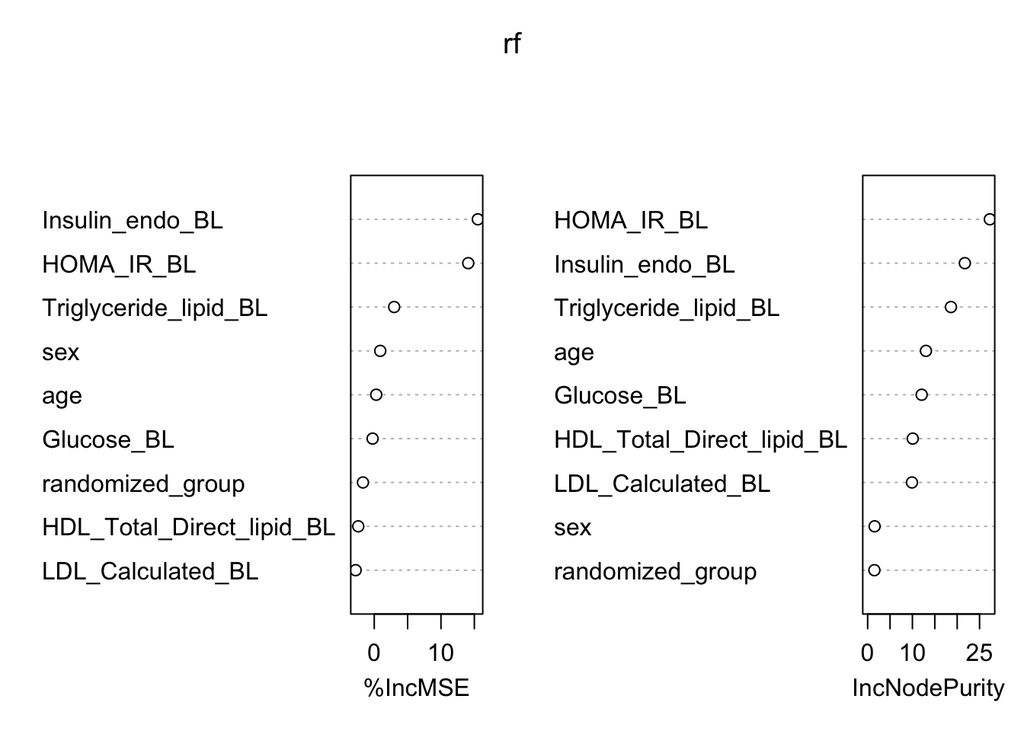

```r
varImpPlot(rf)
```

### Prediction and Calculate Performance Metrics

```r
# Get predictions
pred1 <- predict(rf)

# Evaluate regression performance
rmse_value <- rmse(train$outcome_BMI_fnl_BL, pred1)
print(paste("RMSE:", rmse_value))
```

```
## [1] "RMSE: 0.94093544095512"
```

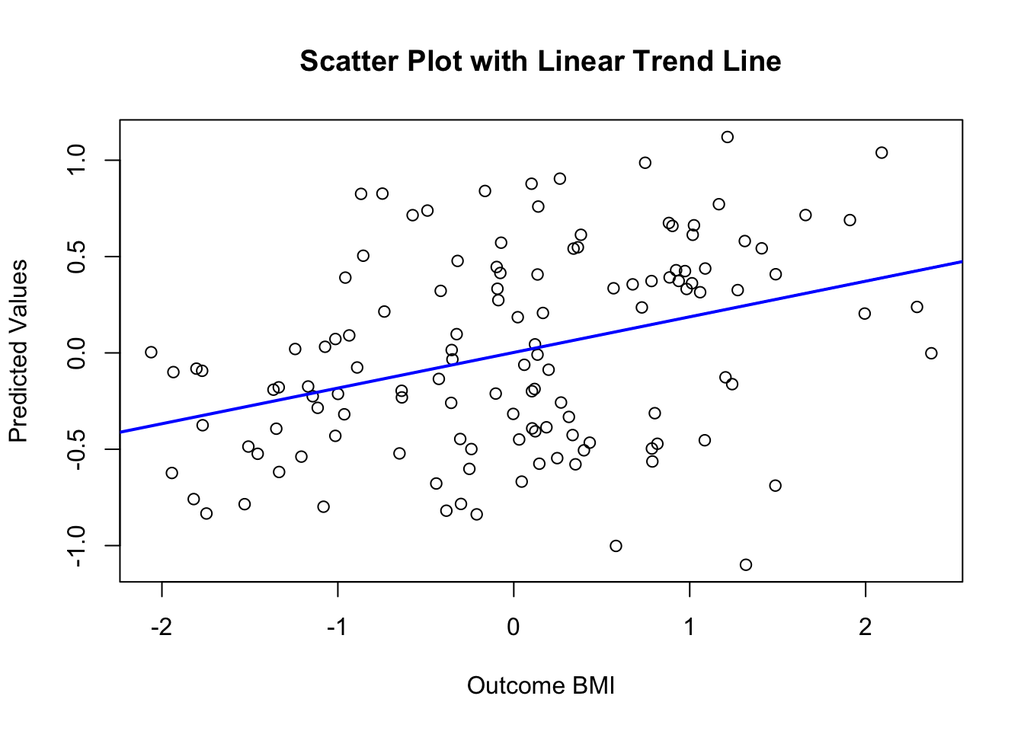

```
## integer(0)
```

```r
# Fit a linear model between actual and predicted
model <- lm(pred1 ~ train$outcome_BMI_fnl_BL)
plot(train$outcome_BMI_fnl_BL, pred1,
     xlab = "Outcome BMI",
     ylab = "Predicted Values",
     main = "Scatter Plot with Linear Trend Line") +
  abline(model, col = "blue", lwd = 2)
```